# Random Forest Classification Analysis

Prelim Analysis

Author

Matt McGehee (Advisor: Dr. Seals)

Published

October 23, 2024

## Analysis

The objective of the following analysis will apply a Random Forest classification model to predict the `SalesOrderStatus` (Fulfilled vs. Unfulfilled) using several predictor variables. This process will follow the steps described in the Methods section, with the analysis performed using the `randomForest` package in R (Liaw and Wiener 2002).

Data cleaning was performed to remove irrelevant line items, such as shipping and customer refunds.

## Load necessary libraries

```r
library(knitr)
library(kableExtra)
library(dplyr)
library(randomForest)
library(caret)
library(pROC)
```

## Loading the Data

Read in the data from the corresponding ‘csv’ file that contains the sales data.

```r
sales_data <- read.csv("data_as_csv.csv")
```

## Data Cleaning and Preprocessing

The raw dataset initially contained some irrelevant products, including shipping line items and “credits” back to customers, which were not relevant to the analysis. To ensure relevancy, the following filtering steps were applied:

- Excluded line items related to shipping and fees, such as “OUTBOUND SHIPPING”, “Shipping Charge”.
- Filtered out negative `UnitPrice`, `TotalPrice`, and `qtyOrdered` values related to refunds.

```r
exclude_products <- c("OUTBOUND SHIPPING", "Outbound Shipping", "Shipping Charge", "SHIPPING CHARGE")

# Filter the data to remove shipping line items and any customer credits
filtered_data <- sales_data %>%
  filter(UnitPrice > 0, TotalPrice > 0, qtyOrdered > 0, !Product %in% exclude_products) %>%
  select(SalesOrderStatus, qtyOrdered, UnitPrice, Substrate, Product) %>%
  filter(!is.na(SalesOrderStatus), !is.na(qtyOrdered), !is.na(UnitPrice), !is.na(Substrate), !is.na(Product))

# Convert SalesOrderStatus to a factor variable
filtered_data$SalesOrderStatus <- as.factor(filtered_data$SalesOrderStatus)

set.seed(123)
```

### Variable Selection

The key variables selected for classification are: - `qtyOrdered`: Reflects the size of the order. - `UnitPrice`: Indicates the price per unit of the product. - `Substrate`: Material type of the product - `Product`: The product being sold.

## Analysis

### Training the Random Forest Model

```r
# Split into training (80%) and testing (20%)
trainIndex <- createDataPartition(filtered_data$SalesOrderStatus, p = 0.8, list = FALSE)
train_data <- filtered_data[trainIndex, ]
test_data <- filtered_data[-trainIndex, ]

rf_model <- randomForest(SalesOrderStatus ~ qtyOrdered + UnitPrice + Substrate + Product,
                         data = train_data,
                         ntree = 100,
                         proximity = TRUE,
                         importance = TRUE)

# Extract model results
model_results <- data.frame(
  Metric = c("Number of Trees", "Variables Tried at Each Split (mtry)", "OOB Estimate of Error Rate"),
  Value = c(rf_model$ntree, rf_model$mtry, paste0(round(rf_model$err.rate[nrow(rf_model$err.rate), "OOB"] * 100, 2), "%"))
)

# Print the model results in a nice table
model_results %>%
  kable("html") %>%
  kable_styling(full_width = F, position = "center", bootstrap_options = c("striped", "hover"))
```

Table 1: Random Forest Model Summary

| Metric | Value |
| --- | --- |
| Number of Trees | 100 |
| Variables Tried at Each Split (mtry) | 2 |
| OOB Estimate of Error Rate | 17.52% |

### Model Evaluation on Test Set

```r
# Predict on test set
test_pred <- predict(rf_model, newdata = test_data)

# Confusion matrix
conf_matrix <- confusionMatrix(test_pred, test_data$SalesOrderStatus)

# Extract the confusion matrix table
conf_matrix_table <- as.data.frame(conf_matrix$table)

# Display Confusion Matrix
conf_matrix_table %>%
  kable("html") %>%
  kable_styling(full_width = F, position = "center", bootstrap_options = c("striped", "hover"))
```

Table 2: Confusion Matrix

| Prediction | Reference | Freq |
| --- | --- | --- |
| Closed Short | Closed Short | 82 |
| Fulfilled | Closed Short | 1241 |
| Closed Short | Fulfilled | 107 |
| Fulfilled | Fulfilled | 4430 |

#### Model Statistics

```r
# Extract relevant statistics from the confusion matrix object
stats <- data.frame(
  Metric = c("Accuracy", "95% CI", "Kappa", "Sensitivity", "Specificity", "Pos Pred Value",
             "Neg Pred Value", "Prevalence", "Detection Rate", "Balanced Accuracy"),
  Value = c(
    round(conf_matrix$overall['Accuracy'], 3),
    paste0("(", round(conf_matrix$overall['AccuracyLower'], 3), ", ", round(conf_matrix$overall['AccuracyUpper'], 3), ")"),
    round(conf_matrix$overall['Kappa'], 3),
    round(conf_matrix$byClass['Sensitivity'], 5),
    round(conf_matrix$byClass['Specificity'], 5),
    round(conf_matrix$byClass['Pos Pred Value'], 5),
    round(conf_matrix$byClass['Neg Pred Value'], 5),
    round(conf_matrix$byClass['Prevalence'], 5),
    round(conf_matrix$byClass['Detection Rate'], 5),
    round(conf_matrix$byClass['Balanced Accuracy'], 5)
  )
)

# Display Model Statistics
stats %>%
  kable("html") %>%
  kable_styling(full_width = F, position = "center", bootstrap_options = c("striped", "hover"))
```

Table 3: Model Statistics

|  | Metric | Value |
| --- | --- | --- |
| Accuracy | Accuracy | 0.77 |
|  | 95% CI | (0.759, 0.781) |
| Kappa | Kappa | 0.055 |
| Sensitivity | Sensitivity | 0.06198 |
| Specificity | Specificity | 0.97642 |
| Pos Pred Value | Pos Pred Value | 0.43386 |
| Neg Pred Value | Neg Pred Value | 0.78117 |
| Prevalence | Prevalence | 0.22577 |
| Detection Rate | Detection Rate | 0.01399 |
| Balanced Accuracy | Balanced Accuracy | 0.5192 |

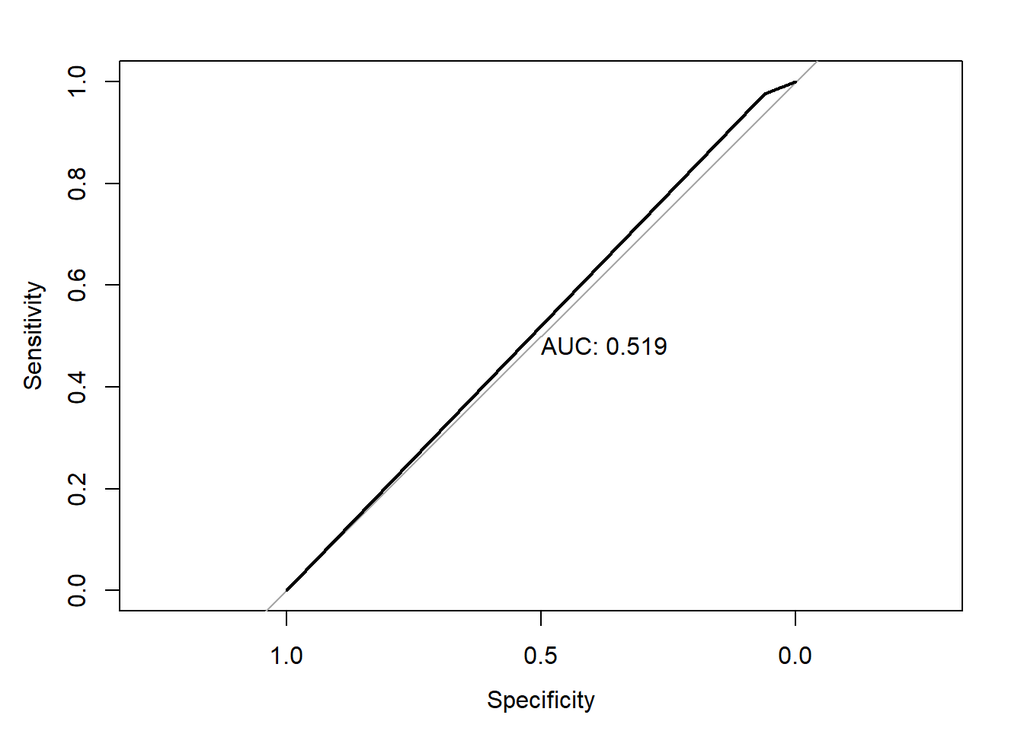

Figure 1: ROC Curve for SalesOrderStatus Classification

```r
# ROC Curve and AUC
roc_curve <- roc(test_data$SalesOrderStatus, as.numeric(test_pred))
plot.roc(roc_curve, print.auc = TRUE)
```

### Feature Importance

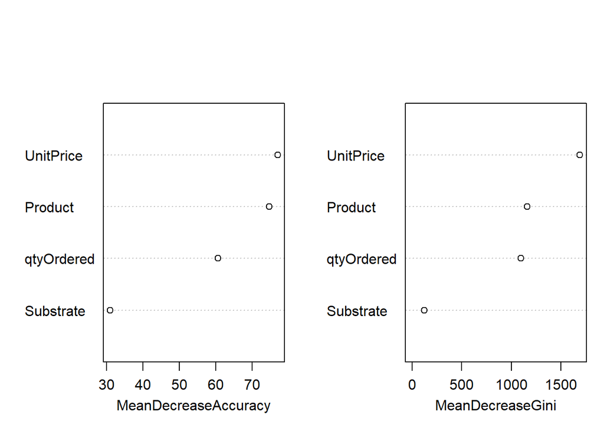

Figure 2: Feature Importance for SalesOrderStatus Classification

```r
# Plot Mean Decrease in Accuracy and Mean Decrease in Gini
varImpPlot(rf_model, main = "")
```

```r
# Retrieve numerical importance values
# Get importance scores
importance_scores <- importance(rf_model)

# Convert importance matrix to a data frame
importance_df <- as.data.frame(importance_scores)

# Add row names (the feature names) as a new column
importance_df$Feature <- rownames(importance_df)

# Reorder columns to display "Feature" first
importance_df <- importance_df[, c("Feature", "MeanDecreaseAccuracy", "MeanDecreaseGini")]

# Display the importance table
importance_df %>%
  kable("html") %>%
  kable_styling(full_width = F, position = "center", bootstrap_options = c("striped", "hover"))
```

Table 4: Random Forest Feature Importance

|  | Feature | MeanDecreaseAccuracy | MeanDecreaseGini |
| --- | --- | --- | --- |
| qtyOrdered | qtyOrdered | 60.68559 | 1094.6309 |
| UnitPrice | UnitPrice | 77.07876 | 1688.8627 |
| Substrate | Substrate | 30.97247 | 122.4385 |
| Product | Product | 74.74477 | 1158.3755 |

## Results

### Model Summary

The Random Forest model (see Table 1) was trained using 100 trees, with two variables being tried at each split (`mtry = 2`). The out-of-bag (OOB) estimate of the error rate was 17.52%, indicating that approximately 17.52% of the predictions made by the model on unseen data are expected to be incorrect.

### Confusion Matrix

The model’s performance was evaluated on the test set using a confusion matrix (see Table 2):

- **82** instances were correctly predicted as “Closed Short.”
- **1241** instances were incorrectly predicted as “Fulfilled” but were actually “Closed Short.”
- **107** instances were incorrectly predicted as “Closed Short” but were actually “Fulfilled.”
- **4430** instances were correctly predicted as “Fulfilled.”

### Model Performance Metrics

The model’s performance was evaluated using standard classification metrics (see Table 3):

- **Accuracy**: The overall accuracy on the test set was 0.77 (77%), indicating that the model correctly classified 77% of the test samples.
- **95% Confidence Interval (CI)**: The accuracy falls within a 95% CI of (0.759, 0.781), reflecting the precision of the estimate.
- **Kappa**: The Kappa statistic, measuring the agreement beyond chance, was 0.055, indicating low agreement beyond random chance.
- **Sensitivity**: The sensitivity (true positive rate) was 0.06198, indicating the model’s low ability to correctly identify “Closed Short” cases.
- **Specificity**: The specificity (true negative rate) was 0.97642, showing that the model was highly accurate in identifying “Fulfilled” cases.
- **Positive Predictive Value (PPV)**: The PPV was 0.43386, meaning that 43.39% of instances predicted as “Closed Short” were correct.
- **Negative Predictive Value (NPV)**: The NPV was 0.78117, showing that 78.12% of the predictions made as “Fulfilled” were correct.
- **Balanced Accuracy**: The balanced accuracy, which accounts for both sensitivity and specificity, was 0.5192.

### Feature Importance

Feature importance was assessed using the metrics of Mean Decrease in Accuracy and Mean Decrease in Gini (see Table 4 Figure 2):

- `UnitPrice` emerged as the most important predictor in terms of both metrics, followed by `Product`, `qtyOrdered`, and `Substrate`.
- Mean Decrease in Accuracy reflects the reduction in model accuracy when each feature is removed.
- Mean Decrease in Gini shows each feature’s contribution to reducing uncertainty (impurity) within the model’s trees.

### Conclusions

The Random Forest model achieved an overall accuracy of 77%, with high specificity but low sensitivity, indicating that it was better at identifying fulfilled orders than unfulfilled ones. `UnitPrice` and `Product` were the most significant predictors in making classification decisions.

## References

Liaw, Andy, and Matthew Wiener. 2002. “Classification and Regression by randomForest.” *R News* 2 (3): 18–22. https://CRAN.R-project.org/doc/Rnews/.